# R을 이용한 텍스트 파일 처리 기초 01

### 2회차에서 배울 내용

- 텍스트 파일 읽고 쓰기
- 텍스트 파일에서 빈도 정보 추출하기
- 텍스트 파일의 인코딩(cp949, utf-8) 변환
- 문자열 검색 및 치환: 정규식(regular expression)
- 메타 정보 만들어보기 (헤더, 챕터 구분)

### 텍스트 파일 읽고 쓰기

#### 1. 텍스트 파일 읽기

```r
filepath <- 'data/english_novels/moby_dick_melville.txt'
doc <- readLines(filepath)
length(doc)
```

```
## [1] 22316
```

1. 1행: 읽을 파일의 경로(path)를 지정하여 filepath라는 변수에 저장한다.
2. 2행: **readLines()** 함수로 텍스트 파일을 읽어들여서 doc이라는 변수에 저장한다. **readLines()**는 텍스트 파일의 라인들을 한번에 모두 읽으라는 의미이다(첫 n개의 라인만 읽을 때는 **readLines(filepath, n = n)**과 같이 n 매개변수를 지정).
3. 3행: 파일이 제대로 읽혔는지 **length()** 함수로 확인해 본다. **length()**는 변수에 저장된 목록의 갯수를 세는 함수이다. 이 경우 **length()** 함수는 파일의 총 라인 수(즉 엔터가 들어간 수)를 계산한다. 총 22,316행임을 알 수 있다. 확인해 보려면 에디터로 같은 파일을 열어서 마지막 행의 라인 수를 확인한다.

#### 2. 읽은 파일의 내용 들여다보기

- 텍스트 파일을 읽은 후 파일의 내용을 살펴보려면 print(변수) 함수를 사용한다.
- 그러나 읽은 텍스트가 총 2만 라인 이상이므로 출력 범위를 넘어선다. 이 때는 파일의 일부분(첫 부분 혹은 끝부분)만 출력할 수 있다.
- **변수[시작점:끝점]**과 같이 인덱스를 사용하여 슬라이싱(slicing)을 한다(슬라이싱: 저장된 문서의 일부분만 잘라낸다는 의미).

```r
doc[1:10]
```

```
##  [1] "The Project Gutenberg eBook of Moby-Dick; or The Whale, by Herman Melville"
##  [2] ""
##  [3] "This eBook is for the use of anyone anywhere in the United States and"
##  [4] "most other parts of the world at no cost and with almost no restrictions"
##  [5] "whatsoever. You may copy it, give it away or re-use it under the terms"
##  [6] "of the Project Gutenberg License included with this eBook or online at"
##  [7] "www.gutenberg.org. If you are not located in the United States, you"
##  [8] "will have to check the laws of the country where you are located before"
##  [9] "using this eBook."
## [10] ""
```

1. 1행: [:10]는 doc의 첫 번째 라인부터 10번째 라인까지 총 10개의 라인을 출력하라는 의미이다. **print(doc[1:10])**와 같이 사용해도 되고 그냥 **doc[1:10]**만 사용해도 된다.

```r
doc[1001:1010]
```

```
##  [1] "wherefore it was that after having repeatedly smelt the sea as a"
##  [2] "merchant sailor, I should now take it into my head to go on a whaling"
##  [3] "voyage; this the invisible police officer of the Fates, who has the"
##  [4] "constant surveillance of me, and secretly dogs me, and influences me in"
##  [5] "some unaccountable way—he can better answer than any one else. And,"
##  [6] "doubtless, my going on this whaling voyage, formed part of the grand"
##  [7] "programme of Providence that was drawn up a long time ago. It came in"
##  [8] "as a sort of brief interlude and solo between more extensive"
##  [9] "performances. I take it that this part of the bill must have run"
## [10] "something like this:"
```

1. 1행: [1001:1010]는 *doc*의 1001번째 라인부터 1010번째 라인까지 읽으라는 의미이다. 즉, 1001, 1002, 1003, 1004, 1005, 1006, 1007, 1008, 1009, 1010번째 라인까지 총 10개 라인을 출력한다.

```r
doc[500]
```

```
## [1] "  “Like Spencer’s Talus with his modern flail He threatens ruin with"
```

1. 1행: [500]은 500번째 라인을 출력하라는 의미이다.

##### 파일의 처음 10개 라인만 출력할 때 아래와 같이 **while** 구문을 사용할 수도 있다.

```r
filepath <- 'data/english_novels/moby_dick_melville.txt'
doc <- readLines(filepath)

i <- 1
while (i < 11) {
  print(doc[i])
  i <- i + 1
}
```

```
## [1] "The Project Gutenberg eBook of Moby-Dick; or The Whale, by Herman Melville"
## [1] ""
## [1] "This eBook is for the use of anyone anywhere in the United States and"
## [1] "most other parts of the world at no cost and with almost no restrictions"
## [1] "whatsoever. You may copy it, give it away or re-use it under the terms"
## [1] "of the Project Gutenberg License included with this eBook or online at"
## [1] "www.gutenberg.org. If you are not located in the United States, you"
## [1] "will have to check the laws of the country where you are located before"
## [1] "using this eBook."
## [1] ""
```

1. 1행: 읽을 파일의 경로를 지정하여 *filepath*라는 변수에 저장한다.
2. 2행: **readLines()** 함수로 텍스트 파일을 읽어들여서 *doc*이라는 변수에 저장한다.
3. 4행: **while** 구문을 사용하기 전에 미리 인덱스 변수 *i*를 1로 설정해 둔다. *i*는 5-7행을 거치면서 값을 1씩 증가시킨다. 즉 읽은 텍스트의 라인들을 순차적으로 하나씩 출력하되 이 인덱스 번호를 이용하여 1부터 10번째 라인까지만 출력하도록 유도한다.
4. 5행: **while** 구문은 “~하는 동안” {…} 내의 명령을 계속 수행하라는 의미이다. 이 때 **while(…)** “~하는”은 {…} 내의 명령이 수행될 조건을 말한다. 여기서는 *i*의 값이 11 미만일 동안, 즉 *i*가 1부터 10까지의 값을 가질 때까지만 {…} 내의 명령을 수행한다.
5. 6행: *i*를 인덱스로 사용하여 *doc*에서 *i*번째 라인을 가져온 후 출력한다(**print()**). **while** 구문이 처음 실행될 때는 이 *i*의 값은 4행에서 미리 지정한 1이다.
6. 7행: 6행에서 i번째 라인을 출력한 후에 *i* 값을 1씩 증가시킨다. 예를 들면, **while** 구문이 처음 돌아갈 때 기존의 *i*는 1이었다. 여기에 1을 더하면 *i*는 2가 되고 이 2를 인덱스로 사용하여 두 번째 **while** 구문을 작동시킨다. 5행에서 *i*가 10이 될 때까지 라는 조건을 부여하였으므로 10행까지만 반복 수행하고 작동을 멈춘다.

#### 읽은 파일을 파일 이름을 바꾸어 저장하기

```r
filepath = 'data/english_novels/moby_dick_melville.txt'
doc <- readLines(filepath)

filepath_1 = 'data/english_novels/modified/moby_dick_melville_duplicate.txt'
writeLines(doc, filepath_1)
```

1. 4행: 저장할 파일의 경로와 이름을 지정하여 *filepath_1*에 할당한다.
2. 5행: **writeLines()** 함수로 읽어온 *doc*을 *filepath_1* 위치에 저장한다.

#### 빈 행 삭제하기

*doc* 파일에서 빈 행들을 삭제하여 새로운 파일 이름으로 저장한다.

```r
filepath <- 'data/english_novels/moby_dick_melville.txt'
doc <- readLines(filepath)

idx <- which(doc == "")
doc_ <- doc[-idx]

filepath_2 = 'data/english_novels/modified/moby_dick_melville_emptyRemoved.txt'
writeLines(doc_, filepath_2)

print(length(doc)); print(length(doc_))
```

```
## [1] 22316
```

```
## [1] 19229
```

1. 4행: **which()** 함수는 벡터의 어떤 요소가 조건에 부합하는지 확인하고 부합하는 요소의 인덱스 값을 반환한다. 여기서 조건은 *doc == ““*, 즉* doc* 라인들 중에서 빈 라인”“과 같은 것(==) 즉 빈 라인인 것을 찾아서 그 인덱스를 반환한다. 이 인덱스는* idx*에 할당된다.
2. 5행: *doc*에서 *idx*에 해당하는 요소 즉 라인들을 제거(-)하여 *doc_*에 저장한다.
3. 7행: 새로 저장한 파일 경로와 이름을 지정한다.
4. 8행: *doc_*을 새 이름으로 저장한다.
5. 10행: *doc*과 *doc_*의 라인 수를 비교해 본다.

```r
filepath <- 'data/english_novels/moby_dick_melville.txt'
doc <- readLines(filepath)
doc <- doc[doc != ""]
```

1. 3행: 위의 4-5행을 한 줄로 줄여서 실행할 수도 있다.

```r
filepath <- 'data/english_novels/moby_dick_melville.txt'
doc <- scan(filepath, what = "char", sep = "\n")
```

1. 2행: **scan()** 함수를 사용하면 빈 라인을 제외하고 읽어올 수 있다. **what**은 읽을 파일에 들어있는 데이터 타입의 종류(character는 문자열(string)이라는 의미), *sep*은 라인의 구분자를 지정한다.

```r
filepath <- 'data/english_novels/moby_dick_melville.txt'
doc <- readLines(filepath)
doc_reduced = doc[844:21959]

filepath_2 <- 'data/english_novels/modified/moby_dick_melville_only_body.txt'
writeLines(doc, filepath_2)
```

#### 파일을 두 개 이상 읽는 방법

- 파일들이 위치한 디렉토리(폴더)를 지정하고
- 그 디렉토리에 있는 파일들의 목록을 읽은 후
- 목록에 있는 파일들을 **readLines()**로 하나씩 읽어서 변수에 저장한다.

```r
target_dir <- "data/english_novels"
target_files <- list.files(path = target_dir, pattern = "txt")
print(target_files)
```

```
## [1] "dracula_Stoker.txt"
## [2] "frankenstein_shelley.txt"
## [3] "moby_dick_melville_chapter_titles.txt"
## [4] "moby_dick_melville.txt"
## [5] "sherlock_holmes_doyle.txt"
```

```r
novels <- list()
for (filename in target_files) {
  doc <- readLines(file.path(target_dir, filename))
  novels[[filename]] <- doc
}

str(novels)
```

```
## List of 5
##  $ dracula_Stoker.txt                   : chr [1:15852] "The Project Gutenberg eBook of Dracula, by Bram Stoker" "" "This eBook is for the use of anyone anywhere in the United States and" "most other parts of the world at no cost and with almost no restrictions" ...
##  $ frankenstein_shelley.txt             : chr [1:7737] "The Project Gutenberg eBook of Frankenstein, by Mary Wollstonecraft Shelley" "" "This eBook is for the use of anyone anywhere in the United States and" "most other parts of the world at no cost and with almost no restrictions" ...
##  $ moby_dick_melville_chapter_titles.txt: chr [1:135] "CHAPTER 1. Loomings." "CHAPTER 2. The Carpet-Bag." "CHAPTER 3. The Spouter-Inn." "CHAPTER 4. The Counterpane." ...
##  $ moby_dick_melville.txt               : chr [1:22316] "The Project Gutenberg eBook of Moby-Dick; or The Whale, by Herman Melville" "" "This eBook is for the use of anyone anywhere in the United States and" "most other parts of the world at no cost and with almost no restrictions" ...
##  $ sherlock_holmes_doyle.txt            : chr [1:12304] "The Project Gutenberg eBook of The Adventures of Sherlock Holmes, by Arthur Conan Doyle" "" "This eBook is for the use of anyone anywhere in the United States and" "most other parts of the world at no cost and with almost no restrictions" .…
```

#### 텍스트에서 챕터 제목 라인만 추출하기

- 챕터 제목의 형식을 먼저 확인하고 이 형식에 맞는 챕터 제목 패턴을 지정한다.
- 이 챕터 제목 패턴을 문서에서 찾는다.
- 정규식에 대한 자세한 내용은 뒷 부분에서 다룬다.

```r
filepath = 'data/english_novels/moby_dick_melville.txt'
doc <- readLines(filepath)
doc_reduced = doc[844:21959]

chapter_name = '^CHAPTER \\d+'

chapter_titles = c()
for (textline in doc_reduced) {
  if (grepl(pattern = chapter_name, x = textline)) {
    # chapter_titles[length(chapter_titles)+1] <- textline
    chapter_titles <- c(chapter_titles, textline)
  }
}

print(chapter_titles[1:5])
```

```
## [1] "CHAPTER 1. Loomings."        "CHAPTER 2. The Carpet-Bag."
## [3] "CHAPTER 3. The Spouter-Inn." "CHAPTER 4. The Counterpane."
## [5] "CHAPTER 5. Breakfast."
```

```r
writeLines(chapter_titles, "data/english_novels/modified/moby_dick_melville_chapter_titles.txt")
```

1. 1-3행: 파일을 읽고 불필요한 라인들(본문 시작 전의 책 정보)을 삭제한 후에 *doc_reduced*에 저장한다.
2. 5행: 챕터에 해당하는 라인을 찾기 위해 챕터 제목의 패턴을 확인하여 *chapter_name*에 저장해 둔다. 제목 형식은 ’^CHAPTER \d+’로서 정규식을 이용하였다. ^는 라인의 제일 앞을 나타내고 \d+는 숫자가 1개 이상인 것을 나타낸다.
3. 7행: 챕터 제목을 저장할 빈 벡터 *chapter_titles*를 **c()**로 만든다.
4. 8행: *doc_reduced*에서 한 라인씩 가져와서 *textline*에 할당하고 이 *textline*에 대해 {…} 내의 명령을 실행한다.
5. 9행: 만약(**if**) *textline*에 챕터 제목 형식 즉 *chapter_name*을 찾을 수 있으면, 즉 조건이 참(true)이면 {…} 내의 명령을 실행한다. 문자열, 여기서는 *textline*에 특정한 문자열 패턴이 있는지 여부를 확인하여 true 혹은 false로 출력해 주는 함수가 **grepl()**이다. 패턴이 있으면 true를, 그렇지 않으면 false를 반환한다.
6. 10행: *textline*에 챕터 제목이 있으면, true이면 이 *textline*을 7행에서 만들어 둔 *chapter_titles*에 하나씩 추가한다. 벡터에 요소를 추가하는 것은 **c()** 함수를 사용하면 편리하다.
7. 15행: *chapter_titles*을 5행까지 출력한다.
8. 16행: **writeLines()** 함수로 *chapter_titles*를 지정된 위치에 텍스트 파일을 저장한다. 제목만 저장할 텍스트 파일의 이름은 moby_dick_melville_chapter_titles.txt로 하였다.

아래와 같이 **grep()** 함수를 써서 보다 간단하게 처리할 수도 있다.

```r
filepath = 'data/english_novels/moby_dick_melville.txt'
doc <- readLines(filepath)
doc_reduced = doc[844:21959]

chapter_name = '^CHAPTER \\d+'

chapter_titles = doc_reduced[grep(chapter_name, doc_reduced)]
print(chapter_titles[1:5])
```

```
## [1] "CHAPTER 1. Loomings."        "CHAPTER 2. The Carpet-Bag."
## [3] "CHAPTER 3. The Spouter-Inn." "CHAPTER 4. The Counterpane."
## [5] "CHAPTER 5. Breakfast."
```

```r
head(chapter_titles)
```

```
## [1] "CHAPTER 1. Loomings."        "CHAPTER 2. The Carpet-Bag."
## [3] "CHAPTER 3. The Spouter-Inn." "CHAPTER 4. The Counterpane."
## [5] "CHAPTER 5. Breakfast."       "CHAPTER 6. The Street."
```

1. 1행: *chapter_titles*의 첫 6행만 출력한다.

```r
tail(chapter_titles)
```

```
## [1] "CHAPTER 130. The Hat."
## [2] "CHAPTER 131. The Pequod Meets The Delight."
## [3] "CHAPTER 132. The Symphony."
## [4] "CHAPTER 133. The Chase—First Day."
## [5] "CHAPTER 134. The Chase—Second Day."
## [6] "CHAPTER 135. The Chase.—Third Day."
```

1. 1행: *chapter_titles*의 마지막 6행만 출력한다.

### 텍스트 파일의 인코딩

- 인코딩(character encoding): 문자를 컴퓨터가 이해할 수 있는 숫자와 기호 등의 부호로 바꾸는 것(기호도 모두 숫자로 변환된다)
- 한글 텍스트 파일에 적용되는 인코딩은 크게 cp949 (혹은 euc-kr)와 utf-8 등 두 가지
- 영어 텍스트 파일에 적용되는 인코딩은 크게 ISO 8859-1, ANSI, utf-8 등 세 가지
- 한글 윈도우 시스템은 cp949 인코딩을, mac과 Linux는 utf-8 인코딩을 기반으로 함
  - 한글 윈도우 시스템에서 utf-8 인코딩 한글 텍스트 파일을 열었을 때 깨져 보이게 되는 이유
  - 다운로드한 텍스트 파일을 메모장 등으로 열었을 때 문자들이 다 깨져 보인다면 문자 인코딩 문제가 원인일 경우가 많음
- 인코딩 문제는 주로 한글 텍스트와 관련된 것으로 영어 텍스트는 컴퓨터 시스템에 따른 인코딩의 영향이 크지 않음.

[figure not shown]

- utf-8으로 인코딩된 한글 텍스트를 윈도우 메모장으로 열면 위 화면처럼 문자들이 깨져 보인다.
- 이 파일을 notepad++ 에디터로 열면 정상적으로 열리고, 제일 하단에 이 파일의 인코딩 정보를 UTF-8으로 보여준다.
- 이 파일은 Encoding 메뉴에서 Convert to ANSI를 선택한 후 ‘다른 이름으로 저장’ 메뉴에서 다른 이름으로 저장 후 윈도우 메모장에서 열면 정상적으로 열린다.

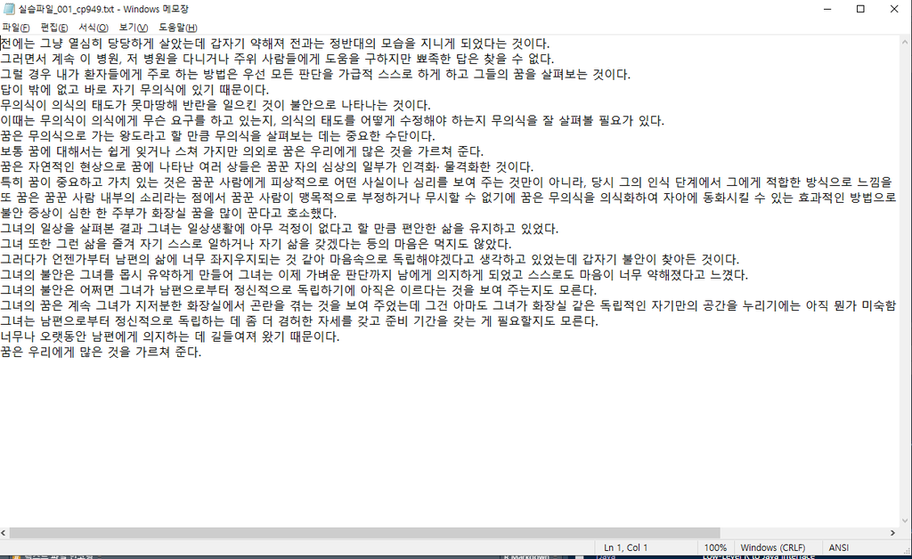

#### Rstudio의 기본 인코딩 설정

- RStudio에서는 기본 인코딩을 변경 설정하는 기능이 있다.
- 이 기본 인코딩을 utf-8으로 설정하는 것을 추천한다.
- RStudio의 Tools 메뉴의 Global options 항목으로 들어간 후 Code > Saving 항목으로 간 후에 default text encoding을 utf-8으로 설정하고 저장한다.

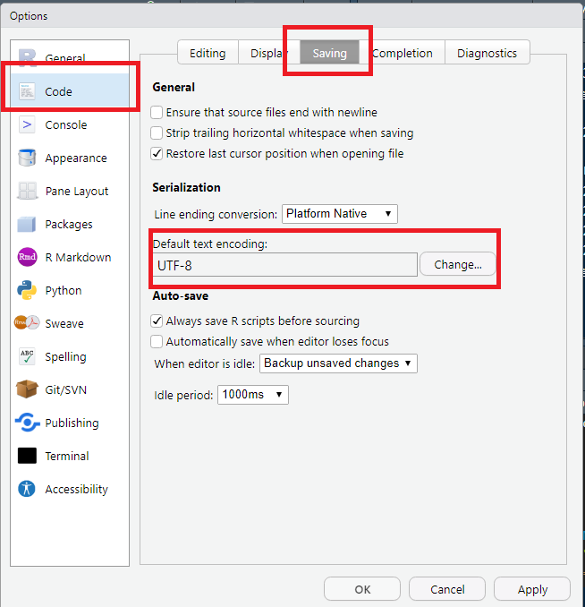

설정 후 utf-8 인코딩 파일을 읽으면 제대로 읽힌다. (* 윈도우즈 시스템에 설치한 R에서는 간혹 한글 텍스트나 특수 문자 등을 읽을 때 깨지는 경우가 발생하는데 Rstudio를 사용하면 문제가 해결된다.)

윈도우즈 시스템에서 utf-8으로 인코딩된 파일을 정상적으로 읽을 수 있다.

```r
txt_path <- "data/korean_novels/삼포 가는 길 - 황석영.txt"
txt <- readLines(txt_path)
print(txt[1:5])
```

```
## [1] ""
## [2] "삼포 가는 길"
## [3] "- 황석영"
## [4] ""
## [5] "영달은 어디로 갈 것인가 궁리해 보면서 잠깐 서 있었다. 새벽의 겨울 바람이 매섭게 불어왔다. 밝아 오는 아침 햇볕 아래 헐벗은 들판이 드러났고, 곳곳에 얼어붙은 시냇물이나 웅덩이가 반사되어 빛을 냈다. 바람 소리가 먼데서부터 몰아쳐서 그가 섰는 창공을 베면서 지나갔다. 가지만 남은 나무들이 수십여 그루씩 들판가에서 바람에 흔들렸다."
```

1. 1행: 대상 텍스트 파일의 위치 경로를 *txt_path* 변수에 저장한다.
2. 2행: 텍스트 파일을 통째로 읽는 **readLines()** 함수를 사용하여 *txt*로 읽어들인다.
3. 4행: *txt*를 1-5행 출력한다.

cp949로 인코딩된 파일을 같은 방식으로 읽었을 때는 글자들이 깨진다.

```r
txt_path <- "data/korean_novels/우리들의 일그러진 영웅 - 이문열.txt"
txt <- readLines(txt_path)

print(txt[1:5])
```

```
## [1] "\xbf츮\xb5\xe9\xc0\xc7 \xc0ϱ\u05f7\xaf\xc1\xf8 \xbf\xb5\xbf\xf5 "
## [2] "\xc0̹\xae\xbf\xad"
## [3] ""
## [4] " \xb9\xfa\xbd\xe1 \xbb\xef\xbd\xca \xb3\xe2\xc0\xcc \xb4\xd9 \xb5\xc5 \xb0\xa1\xc1\xf6\xb8\xb8, \xb1\xd7\xc7\xd8 \xba\xbd\xbf\xa1\xbc\xad \xb0\xa1\xc0\xbb\xb1\xee\xc1\xf6\xc0\xc7 \xbfܷӰ\xed \xc8\xfb\xb5\xe9\xbe\xfa\xb4\xf8 \xbdο\xf2\xc0\xbb \xb5\xb9\xc0\xcc\xc4\xd1 \xba\xb8\xb8\xe9 \xbe\xf0\…
## [5] " \xc0\xda\xc0\xaf\xb4\xe7 \xc1\xa4\xb1\xc7\xc0\xcc \xbe\xc6\xc1\xf7\xc0\xba \xb1\xd7 \xb8\xb6\xc1\xf6\xb8\xb7 \xb1\xe2\xbd\xc2\xc0\xbb \xbaθ\xae\xb0\xed \xc0ִ\xf8 \xb1\xd7\xc7\xd8 \xbb\xef \xbf\xf9 \xc1\u07fc\xf8, \xb3\xaa\xb4\xc2 \xb1\u05f6\xa7\xb2\xaf \xc0ڶ\xfb\xbd\xba\xb7\xb9 \xb4ٴϴ\xf8 \…
```

#### **iconv**를 이용한 인코딩 변환

notepad++를 이용하여 인코딩을 utf-8으로 변환 후 다시 저장하는 방법도 있으나 R에서 바로 처리할 수도 있다.

```r
txt_path <- "data/korean_novels/우리들의 일그러진 영웅 - 이문열.txt"
txt <- readLines(txt_path)
txt_converted <- iconv(x= txt, from = "cp949", "utf-8")

print(txt[1:3]); print(txt_converted[1:3])
```

```
## [1] "\xbf츮\xb5\xe9\xc0\xc7 \xc0ϱ\u05f7\xaf\xc1\xf8 \xbf\xb5\xbf\xf5 "
## [2] "\xc0̹\xae\xbf\xad"
## [3] ""
```

```
## [1] "우리들의 일그러진 영웅 " "이문열"
## [3] ""
```

1. 1행: 대상 텍스트 파일의 위치 경로를 저장한다.
2. 2행: 텍스트 파일을 통째로 읽는 **readLines()** 함수로 읽어들여 *txt* 변수에 할당한다.
3. 3행: 읽어들인 텍스트 파일의 인코딩을 **iconv()** 함수를 이용하여 cp949에서 utf-8으로 변환한 후, *txt_converted* 변수에 다시 저장한다.
4. 5행: cp949 파일을 인코딩 변환없이 읽은 내용과 utf-8으로 인코딩 변환한 내용을 각각 3행씩 출력한다. 이 때는 []와 인덱스를 사용하여 출력할 라인을 지정한다.

### 텍스트 파일 전처리: 정규식(regular expressions)

- 정규식: 문자열의 검색과 치환을 위한 형식 언어이다. 텍스트 파일을 처리할 때 가장 많이 수행하는 작업 중 하나가 정규식을 이용한 문자열 검색과 문자열 찾기/바꾸기이다.
- 몇 개의 파일을 대상으로 고정된 형태의 문자열을 찾기/바꾸기하는 것은 워드프로세서로도 가능하지만 대량의 파일을 처리할 때는 워드프로세서로 처리하는 것이 쉽지 않다.
- 고정된 문자열이 아닌 가변형의 문자열은 정규식을 이용해야 한다.
- 정규식의 문법 체계와 활용 범위는 아주 방대하므로 여기서는 텍스트를 다룰 때 가장 기본적인 것 몇 가지만 소개한다.
  - 보다 다양한 정규식 형태에 대한 설명은 https://www.regular-expressions.info/나 https://rstudio-pubs-static.s3.amazonaws.com/74603_76cd14d5983f47408fdf0b323550b846.html 등을 참고하면 된다.

#### 정규식을 이용한 문자열의 검색과 치환

- 정규식을 이용한 문자열 찾기는 **grep()**, **grepl()**, 문자열 치환은 **sub()**, **gsub()** 함수를 사용한다.
  - **grep()** 함수는 찾고자 하는 문자열 패턴의 위치를 반환한다.
  - **grepl()** 함수는 찾고자 하는 문자열이 존재하는지 아닌지를 논리값(T/F)으로 반환한다.
  - **sub()** 함수는 찾는 문자열 중 첫 번째로 발견한 문자열을 원하는 다른 문자열로 변환한다.
  - **gsub()** 함수는 찾는 문자열 전부를 을 원하는 다른 문자열로 변환한다.

###### 메타 문자

- 메타 문자는 정규식에서 특수한 의미를 가지는 문자 집합으로 일반적인 텍스트 내의 문자와는 다른 의미를 가진다.
- 메타 문자를 일반 문자로 인식하려면 해당 문자 앞에 ’\\’를 붙여야 한다.
- 메타 문자의 종류에는 다음과 같은 것들이 있다.

. ^ $ * + ?  
{ } [ ] | ( )

##### 기본적인 정규식 패턴 (문자 패턴)

| 정규식 패턴 | 의미 |
| --- | --- |
| [가나다] | ‘가’ 혹은 ‘나’ 혹은 ‘다’ 검색 |
| [abc] | ‘a’ 혹은 ‘b’ 혹은 ‘c’ 검색 |
| [0-9] | 0에서 9까지의 숫자 검색 |
| [a-zA-Z] | 알파벳 소문자 a에서 z까지, 대문자 A에서 Z까지 전체 검색 |
| [가-힣ㄱ-ㅎ] | 한글 문자 ‘가’에서 ’힣’(가, 각, 갂, …, 힡, 힢, 힣), 자음 ’ㄱ’에서 ’ㅎ’까지 전체 검색 |
| [a-zA-Z0-9] | 알파벳 소문자 a에서 z까지, 대문자 A에서 Z까지, 숫자 0에서 9까지 검색 |
| . | 줄바꿈 문자인 제외한 임의의 한 문자 검색(아무 문자나 검색) |
| \\d | 숫자 검색 |
| \\s | 공백 검색 |

##### 기본적인 정규식 패턴 (문자 반복)

| 정규식 패턴 | 의미 |
| --- | --- |
| + | 앞 문자의 패턴이 1개 이상 있음 |
| * | 앞 문자의 패턴이 0개 혹은 1개 이상 있음 |
| ? | 앞 문자가 0개이거나 1개 있음 |
| {m, n} | 앞 문자 패턴이 m개 이상 n개 이하 있음 |
| {m,} | 앞 문자 패턴이 m개 이상 있음 |
| {n} | 앞 문자 패턴이 n개 있음 |

##### 기본적인 정규식 패턴 (기타)

| 정규식 패턴 | 의미 |
| --- | --- |
| ^ | 문자열의 시작을 의미 |
| $ | 문자열의 끝을 의미 |
| \| | A 또는 B (or) |
| & | A 그리고 B (and) |

##### 문자열 찾기

```r
ex <- 'an example word:cat!!'
searched <- regexpr(pattern='word:...', text = ex)

if (searched[1] > 0) {
  print(substr(x = ex,
               start = searched,
               stop = searched + attr(searched, "match.length") - 1))
} else {
  print('Nothing')
}
```

```
## [1] "word:cat"
```

1. 1행: 예시 문장을 *ex*에 할당한다.
2. 2행: 정규식 패턴을 찾는 함수 **regexpr()**을 사용하여 일치하는 문자열을 찾는다. 이 값은 *searched*에 저장된다. *searched*에는 일치하는 문자열의 시작 위치와 일치하는 문자열의 길이 정보가 저장된다.
3. 4-7행: 만약(**if**) *searched*의 첫 번째 요소, 즉 일치하는 문자열의 위치가 1 이상이면 **substr()** 함수로 일치하는 문자열을 찾아 출력한다. **substr()** 함수는 대상이 되는 문자열, 시작 위치, 끝 위치 등 세 개를 할으로 가진다.
4. 8-9행: 그렇지 않으면(**else**) ’Nothing’을 출력한다.

#### **grep()**, **grepl()** 함수의 차이

```r
print(grep(pattern = 'a', x = c('aba', 'def')))
```

```
## [1] 1
```

```r
print(grepl(pattern = 'a', x = c('aba', 'def')))
```

```
## [1]  TRUE FALSE
```

1. 1행: **grep()** 함수는 문자열 벡터 *c(‘aba’, ‘def’)*에서 ’a’라는 문자가 있는 요소의 위치, 인덱스를 반환한다.
2. 2행: **grepl()** 함수는 ’a’라는 문자가 문자열 벡터 *c(‘aba’, ‘def’)*에 있는지 여부를 논리값으로 반환한다.

#### 특정 패턴의 단어 추출: **grepl()** 함수

```r
filepath <- 'data/word_lists/english_wordlist.txt'
wordlist <- readLines(filepath)

searched_1 = c()
searched_2 = c()
searched_3 = c()
for (word in wordlist) {
  if (grepl('ed$', word)) {
    searched_1 <- c(searched_1, word)
  } else if(grepl('..j..t..$', word)) {
    searched_2 <- c(searched_2, word)
  } else if(grepl('^[ghi][mno][jlk][def]$', word)) {
    searched_3 <- c(searched_3, word)
  }
}
```

```r
print(searched_1[1:10]); print(searched_2[1:10]); print(searched_3)
```

```
##  [1] "abaissed"  "abandoned" "abased"    "abashed"   "abatised"  "abed"
##  [7] "aborted"   "abridged"  "abscessed" "absconded"
```

```
##  [1] "abjectly"       "adjuster"       "coprojector"    "dejectly"
##  [5] "injector"       "interjector"    "majestic"       "microprojector"
##  [9] "munjistin"      "objectee"
```

```
## [1] "gold" "golf" "hold" "hole"
```

1. 14행: *searched_1*의 10개 요소, *searched_2*의 10개 요소, *searched_3* 전체 요소를 출력한다.

```r
filepath <- 'data/word_lists/chat_words.txt'
chatwords <- readLines(filepath)

searched_1 = c()
searched_2 = c()
searched_3 = c()
for (word in chatwords) {
  if (grepl('^m+i+n+e+$', word)) {
    searched_1 <- c(searched_1, word)
  } else if(grepl('^m*i*n*e*$', word)) {
    searched_2 <- c(searched_2, word)
  } else if(grepl('^[ha]+$', word)) {
    searched_3 <- c(searched_3, word)
  }
}
```

```r
print(searched_1[1:10]); print(searched_2[1:10]); print(searched_3)
```

```
##  [1] "miiiiiiiiiiiiinnnnnnnnnnneeeeeeeeee" "miiiiiinnnnnnnnnneeeeeeee"
##  [3] "mine"                                "mmmmmmmmiiiiiiiiinnnnnnnnneeeeeeee"
##  [5] NA                                    NA
##  [7] NA                                    NA
##  [9] NA                                    NA
```

```
##  [1] ""               "e"              "i"              "in"
##  [5] "m"              "me"             "meeeeeeeeeeeee" "mi"
##  [9] "min"            "mm"
```

```
##  [1] "a"                                "aaaaaaaaaaaaaaaaa"
##  [3] "aaahhhh"                          "ah"
##  [5] "ahah"                             "ahahah"
##  [7] "ahh"                              "ahhahahaha"
##  [9] "ahhh"                             "ahhhh"
## [11] "ahhhhhh"                          "ahhhhhhhhhhhhhh"
## [13] "h"                                "ha"
## [15] "haaa"                             "hah"
## [17] "haha"                             "hahaaa"
## [19] "hahah"                            "hahaha"
## [21] "hahahaa"                          "hahahah"
## [23] "hahahaha"                         "hahahahaaa"
## [25] "hahahahahaha"                     "hahahahahahaha"
## [27] "hahahahahahahahahahahahahahahaha" "hahahhahah"
## [29] "hahhahahaha"
```

1. 14행: *searched_1*의 10개 요소, *searched_2*의 10개 요소, *searched_3* 전체 요소를 출력한다.

```r
filepath <- 'data/word_lists/treebank_words.txt'
treebankwords <- readLines(filepath)

searched_1 = c()
searched_2 = c()
searched_3 = c()
searched_4 = c()
for (word in treebankwords) {
  if (grepl('^[0-9]+\\.[0-9]+$', word)) {
    searched_1 <- c(searched_1, word)
  } else if(grepl('^[0-9]{4}$', word)) {
    searched_2 <- c(searched_2, word)
  } else if(grepl('^[0-9]+-[a-z]{3,5}$', word)) {
    searched_3 <- c(searched_3, word)
  } else if (grepl('(ed|ing)$', word)) {
    searched_4 <- c(searched_4, word)
  }
}
```

```r
print(searched_1[1:10]); print(searched_2[1:10]); print(searched_3); print(searched_4[1:10])
```

```
##  [1] "0.0085" "0.05"   "0.1"    "0.16"   "0.2"    "0.25"   "0.28"   "0.3"
##  [9] "0.4"    "0.5"
```

```
##  [1] "1614" "1637" "1787" "1901" "1903" "1917" "1925" "1929" "1933" "1934"
```

```
##  [1] "10-day"    "10-lap"    "10-year"   "100-share" "12-point"  "12-year"
##  [7] "14-hour"   "15-day"    "150-point" "190-point" "20-point"  "20-stock"
## [13] "21-month"  "237-seat"  "240-page"  "27-year"   "30-day"    "30-point"
## [19] "30-share"  "30-year"   "300-day"   "36-day"    "36-store"  "42-year"
## [25] "50-state"  "500-stock" "52-week"   "69-point"  "84-month"  "87-store"
## [31] "90-day"
```

```
##  [1] "62%-owned"  "Absorbed"   "According"  "Adopting"   "Advanced"
##  [6] "Advancing"  "Alfred"     "Allied"     "Annualized" "Anything"
```

#### 어간과 어미 분리하기(stemming)

```r
pattern = '^.*((ing|ly|ed|ist|ious|ies|ive|es|ment|ness))$'

filepath <- 'data/word_lists/english_wordlist.txt'
wordlist <- readLines(filepath)

word_endings <- c()
for (word in wordlist) {
    stemming <- grepl(pattern, word)
  if (stemming) {
    ending <- sub(pattern = pattern, replacement = "\\1", x = word)
    word_endings <- c(word_endings, ending)
  }
}

word_endings <- sort(table(word_endings), decreasing = TRUE)
print(word_endings)
```

```
## word_endings
##    ly    ed  ness   ing   ist   ive  ment  ious    es
## 11396  9148  6933  5492  2893  2080  1489   855   603
```

1. 1행: 찾고자 하는 어미 패턴을 *pattern* 변수에 저장한다. ’^.*’는 아무 문자나 0번 혹은 1번 이상 나타나는 단어를 말한다. (ing|ly|ed|ist|ious|ies|ive|es|ment|ness)는 |를 사용하여 10개 문자열을 or로 연결한 패턴의 그룹이다. 즉 ing 혹은 ly 혹은 … ness 앞에, 아무 문자(.)나 0번 혹은 1번 이상 나타나는 모든 단어들을 말한다.
2. 3-4행: 영어 단어 목록을 담은 텍스트 파일을 읽어 *wordlist*에 저장한다.
3. 6행: 접미사 목록을 저장할 빈 벡터 *word_endings*를 만든다.
4. 7행: *wordlist*에서 단어를 하나씩 가져와서 *word*에 할당한 후
5. 8행: *word*에서 1행에서 지정한 패턴에 해당하는 문자열이 있을 경우 {…} 내의 명령을 실행한다.
6. 9행: 만약(**if**) *stemming*이 TRUE일 경우
7. 10행: *word*에서 어미 패턴만 남기고 나머지는 삭제한다. 이 때 사용하는 함수가 **sub()**이다. 이 함수의 첫 번째 항은 찾을 패턴, 두 번째 항은 대체 패턴(replacement), 세 번째 항은 대상 문자열이다.
8. 11행: 어미 *ending*을 6행에서 만들어 놓은 *word_endings*에 차례대로 저장한다.
9. 13행: *word_endings*의 빈도 벡터를 만들고(**table(word_endings)**) 이를 내림차순으로 정렬한다(**sort(x, decreasing = TRUE)**).
10. 14행: 빈도 목록을 출력한다.

```r
pattern_1 <- '^(.*?)((ing|ly|ed|ist|ious|ies|ive|es|ment|ness))$'

word_divisions <- list()
for (word in wordlist) {
  matched <- grepl(pattern = pattern_1, word)
  if (matched) {
    root <- sub(pattern = pattern_1, replacement = "\\1", word)
    ending <- sub(pattern = pattern_1, replacement = "\\2", word)
    division <- c(root, ending)
    word_divisions[[word]] <- division
    # word_divisions[[length(word_divisions)+1]] <- division
  }
}

result_filepath <- "result/word_root_endings.txt"
for (word in word_divisions) {
  root_ending = paste(word[1], word[2], sep = "\t")
  write(root_ending, file = result_filepath, append = TRUE)
}

# sprintf("The total list has %s words.", length(word_divisions))
print(paste("The total list has", length(word_divisions), "words."))
```

```
## [1] "The total list has 40889 words."
```

1. 1행: 찾고자 하는 패턴을 *pattern_1* 변수에 저장한다. 바로 위의 *pattern*과 차이는 ‘.*’ 대신 ‘(.*?)’이 사용된 점이다. 정규식 메타 문자 *는 매칭 가능한 최대 범위의 문자열을 찾는 반면, ?를 추가하면 매칭 가능한 최소한의 문자열을 찾는다. 둘의 차이점은 아래의 코드 블록에서 설명한다(* 단, 위 코드에서는 ?를 사용하지 않아도 원하는 결과를 얻을 수 있다).’^(.*?)(ing|ly|ed|ist|ious|ies|ive|es|ment|ness)$‘는 아무 문자로 시작하되 ing, ly, ed, … 등으로 끝나는 단어를 찾으라는 의미이다. ()는 그룹을 지정하기 위한 것으로’(.*?)’와 (ing|ly|ed|ist|ious|ies|ive|es|ment|ness) 등 두 개를 각개의 그룹으로 취급한다는 의미이다. 즉 패턴에 맞는 단어가 나타날 경우 첫 번째 괄호에 해당하는 어간과 두 번째 괄호에 해당하는 어미를 분리하여 저장한다.
2. 3행: 단어의 어간(root, stem)과 어미(ending)를 함께 저장할 빈 리스트 *word_divisions*을 만든다. 이 변수는 리스트로서 벡터를 요소로 가질 수 있다.
3. 4행: *wordlist*의 각 *word*에 대해
4. 5행: *pattern_1*과 일치하는지 확인하고
5. 6행: 만약 패턴에 일치하면 (즉 *matched* 값이 TRUE이면) {…} 내의 명령을 실행한다.
6. 7행: **sub()** 함수로 ’(.*?)’에 해당하는 패턴을 추출한다. 즉 지정한 어미 앞에 오는 어간만 추출하여 *root*에 저장한다.
7. 8행: **sub()** 함수로 ’(ing|ly|ed|ist|ious|ies|ive|es|ment|ness)’에 해당하는 패턴을 추출한다. 즉 지정한 어미만 추출하여 *ending*에 저장한다.
8. 9행: *root*와 *ending*을 하나의 벡터로 만들어 *division*에 저장한다.
9. 10행: 어간과 어미 정보를 저장하기 위해 만든 빈 리스트 *word_divisions*에 *division*을 저장한다. 리스트에 요소를 추가하기 위해서는 각 요소에 이름을 지정하거나 인덱스 번호를 주어야 한다. 여기서는 *word*를 리스트를 구성하는 요소의 이름으로 사용하였다.
10. 15행: 어간/어미 분리 정보를 쓸 파일 경로와 이름을 *result_filepath*로 지정한다.
11. 16행: *word_divisions*에서 벡터를 하나씩 가져와서 *word*에 할당하고 이 *word*에 대해 {…} 내의 명령을 실행한다. 즉 한 줄에 하나의 *word*를 차례대로 쓴다.
12. 17행: *word*는 어간과 어미 등 두 개의 요소로 이루어진 벡터이다. 이 벡터의 첫 번째 요소 *word[1]*은 어간, 두 번째 요소 *word[2]*는 어미이다. **paste()** 함수로 이 두 개 요소를 tab 기호(\t)와 함께 하나로 결합하여 *root_ending*에 저장한다.
13. 18행: *root_ending*을 *result_filepath*에 저장한다. 이 때 한 줄씩 순차적으로 쓰되, 이미 쓴 내용은 지우지 않고 이어서 써야 하므로 **append** 항을 TRUE로 지정한다.
14. 22행: *word_divisions* 즉 어간과 어미로 분리되는 어휘의 수를 확인하기 위해 **length(word_divisions)**을 **print()** 함수로 출력해 본다.

#### **grep()** 함수를 이용하여 영어 문장과 한국어 문장을 찾아 출력하기

```r
sents <- c("Social worker: Great. Did you bring it with you?",
          "사회복지사: 잘 하셨어요. 일기 가지고 오셨나요?",
          "Joker: (dodging the subject) I'm sorry. Did I bring what?",
          "조커: (못 들은 체하며) 죄송합니다. 뭐라고 하셨죠?",
          "Joker: What time?",
          "조커: 몇 신가요?",
          "Social Worker: It's 2:45.",
          "사회복지사: 2시 45분이예요.",
          "Social Worker: 전화번호를 기입하셔야 해요.",
          "사회복지사: 2시 45분이예요.",
          "Joker: What time?",
          "조커: 몇 신가요?")

print(sents)
```

```
##  [1] "Social worker: Great. Did you bring it with you?"
##  [2] "사회복지사: 잘 하셨어요. 일기 가지고 오셨나요?"
##  [3] "Joker: (dodging the subject) I'm sorry. Did I bring what?"
##  [4] "조커: (못 들은 체하며) 죄송합니다. 뭐라고 하셨죠?"
##  [5] "Joker: What time?"
##  [6] "조커: 몇 신가요?"
##  [7] "Social Worker: It's 2:45."
##  [8] "사회복지사: 2시 45분이예요."
##  [9] "Social Worker: 전화번호를 기입하셔야 해요."
## [10] "사회복지사: 2시 45분이예요."
## [11] "Joker: What time?"
## [12] "조커: 몇 신가요?"
```

1. 1행: *sents*라는 변수를 설정 후 총 12개의 문장(영어/한국어 대사)을 할당한다. 하나 이상의 요소를 변수에 할당할 때에는 **c()** 함수를 사용한다.
2. 2행: *sents* 내용을 출력한다.

```r
eng_pattern <- "^[a-zA-Z]+"
# kor_pattern <- "^[가-힣ㄱ-ㅎㅏ-ㅡ]+"

for (sent in sents) {
  if (grepl(eng_pattern, sent)) {
    print(paste(sent, " -> is an English sentence."))
  } else {
    print(paste(sent, "-> is an Korean sentence."))
  }
}
```

```
## [1] "Social worker: Great. Did you bring it with you?  -> is an English sentence."
## [1] "사회복지사: 잘 하셨어요. 일기 가지고 오셨나요? -> is an Korean sentence."
## [1] "Joker: (dodging the subject) I'm sorry. Did I bring what?  -> is an English sentence."
## [1] "조커: (못 들은 체하며) 죄송합니다. 뭐라고 하셨죠? -> is an Korean sentence."
## [1] "Joker: What time?  -> is an English sentence."
## [1] "조커: 몇 신가요? -> is an Korean sentence."
## [1] "Social Worker: It's 2:45.  -> is an English sentence."
## [1] "사회복지사: 2시 45분이예요. -> is an Korean sentence."
## [1] "Social Worker: 전화번호를 기입하셔야 해요.  -> is an English sentence."
## [1] "사회복지사: 2시 45분이예요. -> is an Korean sentence."
## [1] "Joker: What time?  -> is an English sentence."
## [1] "조커: 몇 신가요? -> is an Korean sentence."
```

1. 1행: 영어 문장을 찾기 위한 패턴을 *eng_pattern*에 지정한다. *eng_pattern*은 문장의 시작이 영어 단어인 것을 찾겠다는 의미이다.
2. 4행: *sents*에서 한 문장씩 가져와 *sent*에 할당하고
3. 5행: 만약 *sent*가 영어 단어로 시작하면
4. 6행: 그 문장과 ” -> is an English sentence.”을 하나로 결합하여 출력한다.
5. 7행: 그렇지 않으면(**else**) 즉 영어 단어로 시작하지 않으면
6. 8행: 그 문장과 ” -> is an Korean sentence.”을 하나로 결합하여 출력한다.

#### sents에서 영어 문장과 한국어 문장을 분리하기

```r
eng_pattern <- "^[a-zA-Z]+"
kor_pattern <- "^[가-힣ㄱ-ㅎㅏ-ㅡ]+"

eng_idx <- grep(eng_pattern, sents)
kor_idx <- grep(kor_pattern, sents)

eng_sents <- sents[eng_idx]
kor_sents <- sents[kor_idx]

print(eng_sents); print(kor_sents)
```

```
## [1] "Social worker: Great. Did you bring it with you?"
## [2] "Joker: (dodging the subject) I'm sorry. Did I bring what?"
## [3] "Joker: What time?"
## [4] "Social Worker: It's 2:45."
## [5] "Social Worker: 전화번호를 기입하셔야 해요."
## [6] "Joker: What time?"
```

```
## [1] "사회복지사: 잘 하셨어요. 일기 가지고 오셨나요?"
## [2] "조커: (못 들은 체하며) 죄송합니다. 뭐라고 하셨죠?"
## [3] "조커: 몇 신가요?"
## [4] "사회복지사: 2시 45분이예요."
## [5] "사회복지사: 2시 45분이예요."
## [6] "조커: 몇 신가요?"
```

1. 1-2행: 영어 문장과 한국어 문장을 찾기 위한 패턴을 각각 지정한다.
2. 4행: **grep()** 함수로 *sents* 중 영어 문장 패턴을 가지고 있는 문장의 인덱스를 구한다. 인덱스는 위치를 나타내는 숫자로 된 벡터이다.
3. 5행: **grep()** 함수로 *sents* 중 한국어 문장 패턴을 가지고 있는 문장의 인덱스를 구한다.
4. 6행: *sents* 중 *eng_idx* 인덱스에 해당하는 문장들만 추출하여 *eng_sents*에 저장한다. 여기서 […]는 subsetting을 위한 기호이다.
5. 7행: *sents* 중 *kor_idx* 인덱스에 해당하는 문장들만 추출하여 *kor_sents*에 저장한다.
6. 9행: *eng_sents*와 *kor_sents*를 출력해 본다.

#### 영어 단어와 한글 단어를 찾아서 출력하기

```r
english_words = c()
korean_words = c()
for (sent in sents) {
  words <- strsplit(x = sent, split = " ")
  words <- unlist(words)
  # words <- unlist(strsplit(x = sent, split = " "))
  for (word in words) {
    if (grepl("[a-zA-Z]+", word)) {
      english_words <- c(english_words, word)
    } else if (grepl("[ㄱ-ㅎ가-힣]+", word)) {
      korean_words <- c(korean_words, word)
    }
  }
}

print(english_words); print(korean_words)
```

```
##  [1] "Social"   "worker:"  "Great."   "Did"      "you"      "bring"
##  [7] "it"       "with"     "you?"     "Joker:"   "(dodging" "the"
## [13] "subject)" "I'm"      "sorry."   "Did"      "I"        "bring"
## [19] "what?"    "Joker:"   "What"     "time?"    "Social"   "Worker:"
## [25] "It's"     "Social"   "Worker:"  "Joker:"   "What"     "time?"
```

```
##  [1] "사회복지사:" "잘"          "하셨어요."   "일기"        "가지고"
##  [6] "오셨나요?"   "조커:"       "(못"         "들은"        "체하며)"
## [11] "죄송합니다." "뭐라고"      "하셨죠?"     "조커:"       "몇"
## [16] "신가요?"     "사회복지사:" "2시"         "45분이예요." "전화번호를"
## [21] "기입하셔야"  "해요."       "사회복지사:" "2시"         "45분이예요."
## [26] "조커:"       "몇"          "신가요?"
```

1. 1-2행: 영어 단어와 한국어 단어를 저장할 빈 벡터들을 만든다.
2. 3행: *sents*에서 문장을 하나씩 가져와서 *sent*에 할당 후
3. 4행: 문장 *sent*를 단어 단위로 분리한다. 이 때 사용하는 함수가 **strsplit()**이다. **strsplit()** 함수는 분리할 대상(문장이나 문서) 그리고 어떤 기준으로 분리할 지를 정하는 구분자(**split**) 등 두 개의 항을 갖는다. 이 때 주의할 점은 **strsplit()**으로 분리한 결과는 벡터가 아니라 리스트로 반환된다는 점이다.
4. 5행: 리스트로 반환된 *words*를 벡터로 만들기 위해 **unlist()** 함수를 사용한다. unlist된 *words*는 문장을 구성하는 각 단어들을 요소로 가지는 벡터이다. 4-5행을 한 줄로 묶어 6행과 같이 처리할 수도 있다.
5. 7행: *words*에서 단어를 하나씩 가져와서 *word*에 할당 후
6. 8행: 이 *word*에 영어 알파벳이 1개 이상 있는 문자열을 검색하고(**grepl()**), 만약(**if()**) 이 결과가 TRUE이면 {…} 내의 명령을 실행한다.
7. 9행: 만약 *word*에 영어 알파벳이 있다면 *english_words*에 저장한다.
8. 10행: 그렇지 않고(**else if()**) *word*에 한글 문자가 있다면 {…} 내의 명령을 실행한다.
9. 11행: 만약 *word*에 한글 문자가 있다면 *korean_words*에 저장한다.
10. 16행: **for()** 구문이 다 실행된 후(즉 모든 문장 *sents*에 대해 영어 단어와 한국어 단어를 찾는 과정이 끝나면) *english_words*와 *korean_words*를 각각 출력해 본다.

```r
all_words <- strsplit(x = sents, split = " ")
all_words <- unlist(all_words)

x <- grep(pattern = "er", x = all_words)
y <- grep(pattern = "어요|나요|니다", x = all_words)
z <- grep(pattern = ":|\\.|\\?", x = all_words)
x_values <- all_words[x]
y_values <- all_words[y]
z_values <- all_words[z]

print(x_values); print(y_values); print(z_values)
```

```
## [1] "worker:" "Joker:"  "Joker:"  "Worker:" "Worker:" "Joker:"
```

```
## [1] "하셨어요."   "오셨나요?"   "죄송합니다."
```

```
##  [1] "worker:"     "Great."      "you?"        "사회복지사:" "하셨어요."
##  [6] "오셨나요?"   "Joker:"      "sorry."      "what?"       "조커:"
## [11] "죄송합니다." "하셨죠?"     "Joker:"      "time?"       "조커:"
## [16] "신가요?"     "Worker:"     "2:45."       "사회복지사:" "45분이예요."
## [21] "Worker:"     "해요."       "사회복지사:" "45분이예요." "Joker:"
## [26] "time?"       "조커:"       "신가요?"
```

##### **gsub()** 함수 사용해 보기

```r
print(gsub(pattern = '\\d{4}', replacement = 'XXXX', x = '010-1234-5678'))
```

```
## [1] "010-XXXX-XXXX"
```

```r
print(gsub(pattern = '\\d{3}', replacement = 'XXX', x = '010-1234-5678'))
```

```
## [1] "XXX-XXX4-XXX8"
```

```r
print(gsub(pattern = '-', replacement = ' ', x = '010-1234-5678'))
```

```
## [1] "010 1234 5678"
```

```r
print(gsub(pattern = 'Tube ', replacement = '', x = 'Tube Ryan'))
```

```
## [1] "Ryan"
```

1. 1행: ’010-1234-5678’라는 대상 문자열(x)에서 숫자(\d)가 4개({4}) 들어간 패턴(pattern)을 찾아서 그 찾은 패턴을 ’XXXX’라는 문자열(replacement)로 바꾼다.
2. 2행: ’010-1234-5678’라는 대상 문자열(x)에서 숫자(\d)가 3개({4}) 들어간 패턴(pattern)을 찾아서 그 찾은 패턴을 ’XXX’라는 문자열(replacement)로 바꾼다.
3. 3행: ’010-1234-5678’라는 대상 문자열(x)에서 구분 기호(-)를 공백으로 바꾼다.
4. 4행: ‘Tube Ryan’이라는 문자열에서 ’Tube’, 즉 Tube와 바로 다음의 공백 패턴을 찾아 그 패턴을 대상 문자열에서 제거한다. 찾은 패턴을 다른 것으로 교체하지 않고 단순히 삭제하고 싶을 때는 바꾸기 패턴(replacement)을 ’’로 하면 된다.

##### *sents*에서 등장인물 이름과 지문을 제거하고 대사만 남기기

```r
sents_no_names_direct = c()

for (sent in sents) {
    x = gsub('^.*: ', '', sent)
    x = gsub('\\(.*\\) ', '', x)
    if (x != "") {
      sents_no_names_direct <- c(sents_no_names_direct, x)
    }
}

print(sents_no_names_direct)
```

```
##  [1] "Great. Did you bring it with you?"  "잘 하셨어요. 일기 가지고 오셨나요?"
##  [3] "I'm sorry. Did I bring what?"       "죄송합니다. 뭐라고 하셨죠?"
##  [5] "What time?"                         "몇 신가요?"
##  [7] "It's 2:45."                         "2시 45분이예요."
##  [9] "전화번호를 기입하셔야 해요."        "2시 45분이예요."
## [11] "What time?"                         "몇 신가요?"
```

1. 1행: 등장인물 이름과 지문을 제거한 새 문장들을 저장할 빈 벡터 *sents_no_names_direct*를 만든다.
2. 3행: *sents*의 문장을 하나씩 꺼내어 *sent*에 할당하고
3. 4행: *sent*에서 등장인물을 표시하는 패턴, 즉 문자열의 제일 처음(^)부터 :과 바로 다음의 공백(: )까지를 ‘^.*: ’로 나타내고 이를 비어있는 패턴 즉’’로 바꾸어 삭제한다. 등장인물 이름이 삭제된 문장을 *x*에 저장한다. 찾기 패턴의 ^는 문자열의 첫 부분, .는 공백/기호/문자 포함 아무 문자, *는 바로 앞의 문자 0개 혹은 1개 이상을 의미한다.
4. 5행: *x*에서 지문, 즉 괄호 ((…))로 묶인 부분을 삭제하여 다시 *x*에 저장한다. 정규식에서 둥근 괄호는 특수한 의미를 가진 기호이므로, 찾고자 하는 괄호가 기호가 아닌 문자임을 나타내도록 이스케이프 문자 \를 붙인다. 이스케이프 문자는 바로 다음의 문자가 특수 기호가 아니라 일반 문자라는 것을 나타낸다(.: 아무 문자 한 개 *vs* .: 문자로서의 마침표).
5. 6-7행: *x*에 값이 빈 값이 아니면(!=) 즉 값이 저장되어 있으면 즉 교체한 문자열이 들어있으면, *x*를 미리 만들어 둔 *sents_no_names_direct*에 하나씩 추가한다.
6. 11행: *sents_no_names_direct*를 출력한다.

##### 문자열 치환: **gsub()** 함수는 특정 문자열을 찾아 그 문자열을 다른 문자열로 바꿀 때 사용한다.

```r
sents_alpha_removed <- gsub(pattern = "[a-zA-Z]", replacement = "", x = sents)

print(sents_alpha_removed)
```

```
##  [1] " : .      ?"
##  [2] "사회복지사: 잘 하셨어요. 일기 가지고 오셨나요?"
##  [3] ": (  ) ' .    ?"
##  [4] "조커: (못 들은 체하며) 죄송합니다. 뭐라고 하셨죠?"
##  [5] ":  ?"
##  [6] "조커: 몇 신가요?"
##  [7] " : ' 2:45."
##  [8] "사회복지사: 2시 45분이예요."
##  [9] " : 전화번호를 기입하셔야 해요."
## [10] "사회복지사: 2시 45분이예요."
## [11] ":  ?"
## [12] "조커: 몇 신가요?"
```

1. 1행: 모든 영문자를 정규식 패턴 ’[a-zA-Z]’으로 찾은 후 모두 공백(““)으로 바꾼다. 즉 모든 영문자를 삭제한다. 찾는 패턴은 **pattern** 인자에, 목표로 하는 패턴은 **replacement** 인자에 넣는다. 대상이 되는 문서는 **x** 인자에 넣는다. 바꾼 결과물을 변수 *sents_alpha_removed*에 할당한다.
2. 3행: 변수 *sents_alpha_removed*를 출력한다.

영문자들이 삭제되고 남은 공백(스페이스)들이 남아 있으므로 남아있는 공백을 삭제하는 과정을 한번 더 거친다(공백도 하나의 문자로 취급).

```r
sents_alpha_removed_cleaned <- gsub(pattern = " +", replacement = "", x = sents_alpha_removed)
print(sents_alpha_removed_cleaned)
```

```
##  [1] ":.?"
##  [2] "사회복지사:잘하셨어요.일기가지고오셨나요?"
##  [3] ":()'.?"
##  [4] "조커:(못들은체하며)죄송합니다.뭐라고하셨죠?"
##  [5] ":?"
##  [6] "조커:몇신가요?"
##  [7] ":'2:45."
##  [8] "사회복지사:2시45분이예요."
##  [9] ":전화번호를기입하셔야해요."
## [10] "사회복지사:2시45분이예요."
## [11] ":?"
## [12] "조커:몇신가요?"
```

1. 1행: 일반적인 공백도 문자로 취급되므로 **pattern** 인자에 ” “와 같이 기입한다. 공백이 하나 이상이므로 메타 문자인”+“를 공백 바로 다음에 붙인다.” +“는”하나 또는 하나 이상의 공백”이라는 의미이다. **replacement**에는 ““를 주어 모든 공백 문자를 삭제한다.
2. 2행: *sents_alpha_removed_cleaned*를 출력한다.

괄호 속의 글자들을 괄호와 함께 모두 삭제할 수도 있다(지문 삭제).

```r
sents_paren_removed <- gsub(pattern = "\\(.*\\)", replacement = "", x = sents)
sents_paren_removed <- gsub(pattern = " +", replacement = " ", x = sents_paren_removed)
print(sents_paren_removed)
```

```
##  [1] "Social worker: Great. Did you bring it with you?"
##  [2] "사회복지사: 잘 하셨어요. 일기 가지고 오셨나요?"
##  [3] "Joker: I'm sorry. Did I bring what?"
##  [4] "조커: 죄송합니다. 뭐라고 하셨죠?"
##  [5] "Joker: What time?"
##  [6] "조커: 몇 신가요?"
##  [7] "Social Worker: It's 2:45."
##  [8] "사회복지사: 2시 45분이예요."
##  [9] "Social Worker: 전화번호를 기입하셔야 해요."
## [10] "사회복지사: 2시 45분이예요."
## [11] "Joker: What time?"
## [12] "조커: 몇 신가요?"
```

1. 1행: 여닫는 괄호는 모두 메타 문자이므로 괄호 문자 자체로 사용하려면 escape 문자 “\”를 바로 앞에 붙여준다. “\(”는 여는 괄호, “\)”는 닫는 괄호를 의미한다. 괄호 내의 “.*”는 아무 문자나 0개 또는 0개 이상을 의미한다. 즉 괄호 속에의 글자들을 의미한다.
2. 2행: 공백이 두 개 이상인 경우 공백 하나로 수정한다.
3. 3행: *sents_paren_removed*를 출력한다.

대사 내의 각 단어/어절에서 구두점을 한번에 모두 없앨 수도 있다.

```r
words <- strsplit(x = sents, split = " ")
words <- unlist(words)
words_punct_removed <- gsub(pattern = "[[:punct:]]", replacement = "", x = words)

print(words_punct_removed)
```

```
##  [1] "Social"     "worker"     "Great"      "Did"        "you"
##  [6] "bring"      "it"         "with"       "you"        "사회복지사"
## [11] "잘"         "하셨어요"   "일기"       "가지고"     "오셨나요"
## [16] "Joker"      "dodging"    "the"        "subject"    "Im"
## [21] "sorry"      "Did"        "I"          "bring"      "what"
## [26] "조커"       "못"         "들은"       "체하며"     "죄송합니다"
## [31] "뭐라고"     "하셨죠"     "Joker"      "What"       "time"
## [36] "조커"       "몇"         "신가요"     "Social"     "Worker"
## [41] "Its"        "245"        "사회복지사" "2시"        "45분이예요"
## [46] "Social"     "Worker"     "전화번호를" "기입하셔야" "해요"
## [51] "사회복지사" "2시"        "45분이예요" "Joker"      "What"
## [56] "time"       "조커"       "몇"         "신가요"
```

##### **strsplit()**의 응용

**strsplit()**이 반환하는 리스트 구조를 이용하면 여러 문장 혹은 문서들의 길이 정보를 한번에 쉽게 구할 수 있다.

```r
splitted <- strsplit(x = sents, split = " ")

# 각 문장의 단어 수를 세어 저장
num_words <- c()
for (sent in splitted) {
  num <- length(sent)
  num_words <- c(num_words, num)
}

# 저장된 각 문장의 단어 수를 하나씩 출력
for (i in 1:length(num_words)) {
  num <- num_words[i]
  print(paste("The sentence ", i, " has ", num, " words.", sep = ""))
}
```

```
## [1] "The sentence 1 has 9 words."
## [1] "The sentence 2 has 6 words."
## [1] "The sentence 3 has 10 words."
## [1] "The sentence 4 has 7 words."
## [1] "The sentence 5 has 3 words."
## [1] "The sentence 6 has 3 words."
## [1] "The sentence 7 has 4 words."
## [1] "The sentence 8 has 3 words."
## [1] "The sentence 9 has 5 words."
## [1] "The sentence 10 has 3 words."
## [1] "The sentence 11 has 3 words."
## [1] "The sentence 12 has 3 words."
```

```r
# print(num_words)
```

1. 1행: 변수 *sents*에 저장된 대사들을 **strsplit()** 함수로 각각 단어로 분리하여 변수 *splitted*에 할당한다.
2. 4행: 각 대사의 길이값을 할당할 변수 *num_words*를 생성한다. 이 변수는 **for** 문을 통해 반환된는 결과값을 담는 그릇 역할을 한다. 벡터 변수는 **c()**로 생성한다.
3. 5행: **for** 문을 이용하여 *splitted*에 저장된 값(**strsplit()**에 의해 분리된 대사)을 하나씩 차례대로 불러와서 *sent*라는 변수에 할당한다.
4. 6행: 변수 *sent*에 저장된 단어의 수를 세어 변수 *num*에 저장한다. 갯수를 세는 함수가 **length()**이다.
5. 7행: 변수 *num*을 3행에서 생성한 변수에 집어넣는다. **c()**에서 첫 번째 인자 *num_words*는 새로운 값이 추가되는 변수이고, 두 번째 인자 *num*은 추가할 새로운 값이다. **c()** 함수는 값들을 차례대로 추가할 때 사용한다.
6. 11행: 1:length(num_words)는 1에서 12(마지막 문장)까지 1씩 증가하는 숫자 벡터를 만들라는 의미이다. 이 숫자 벡터에서 숫자를 하나씩 가져와서 *i*에 할당한 후
7. 12행: *num_words*에서 *i*번째 값(즉 *i*번째 문장의 단어 수)을 *num*에 저장한다.
8. 13행: **paste()** 함수를 이용하여 *num* 값을 출력한다.
[^1]: ghi
[^2]: ha